# Google Data Analytics Case Study (Bike-Share)

Raddad Numan

2022-03-20

## Introduction

This is the final capstone for the Google data analytics program, this case study will let me apply many skills I have gained to a real world data set, to drive business dicisions.

## About the company

In 2016, Cyclistic launched a successful bike-share offering. Since then, the program has grown to a fleet of 5,824 bicycles that are geotracked and locked into a network of 692 stations across Chicago. The bikes can be unlocked from one station and returned to any other station in the system anytime.

### Cyclistic:

A bike-share program that features more than 5,800 bicycles and 600 docking stations. Cyclistic sets itself apart by also offering reclining bikes, hand tricycles, and cargo bikes, making bike-share more inclusive to people with disabilities and riders who can’t use a standard two-wheeled bike.

## Ask Phase

### Identifying the business task.

- The differences between casual riders and the annual members, and how to consider them or other factors to encourage casual riders to buy annual memberships.
- digital media marketing strategy to increase the annual members.

## Prepare Phase

### Data source

> Data has been downloaded from [Motivate International Inc](https://divvy-tripdata.s3.amazonaws.com/index.html). under the [License](https://www.divvybikes.com/data-license-agreement).

> The data was properly stored locally with copies have been stored securely on Google Drive.the data is organized by month, with (.CSV) format. for the twelve months of 2021.

> We will assume that the data is credible since it’s public and provided by the google data analytics program. .

## Using Rstudio to begin cleaning and combining the data

### Installing the required packages

```r
install.packages("tidyverse", repos = "http://cran.us.r-project.org")
install.packages("tidyverse", repos = "http://cran.us.r-project.org")
install.packages("lubridate", repos = "http://cran.us.r-project.org")
install.packages("janitor", repos = "http://cran.us.r-project.org")
install.packages("skimr", repos = "http://cran.us.r-project.org")
```

```r
install.packages("ggplot2", repos = "http://cran.us.r-project.org")
```

### Calling the installed packages

```r
library("tidyverse")
library("lubridate")
library("skimr")
library("janitor")
```

```r
library("ggplot2")
```

### Importing the Data

```r
divvy202101 <- read_csv("202101-divvy-tripdata.csv")
divvy202102 <- read_csv("202102-divvy-tripdata.csv")
divvy202103 <- read_csv("202103-divvy-tripdata.csv")
divvy202104 <- read_csv("202104-divvy-tripdata.csv")
divvy202105 <- read_csv("202105-divvy-tripdata.csv")
divvy202106 <- read_csv("202106-divvy-tripdata.csv")
divvy202107 <- read_csv("202107-divvy-tripdata.csv")
divvy202108 <- read_csv("202108-divvy-tripdata.csv")
divvy202109 <- read_csv("202109-divvy-tripdata.csv")
divvy202110 <- read_csv("202110-divvy-tripdata.csv")
divvy202111 <- read_csv("202111-divvy-tripdata.csv")
divvy202112 <- read_csv("202112-divvy-tripdata.csv")
```

#### Comparing the individual data frames structure and making them ready to combine them into one large data set for further analysis.

#### To view the first six rows of the first data frame

```r
head(divvy202101)
```

```
## # A tibble: 6 × 13
##   ride_id rideable_type started_at          ended_at            start_station_n…
##   <chr>   <chr>         <dttm>              <dttm>              <chr>
## 1 E19E6F… electric_bike 2021-01-23 16:14:19 2021-01-23 16:24:44 California Ave …
## 2 DC88F2… electric_bike 2021-01-27 18:43:08 2021-01-27 18:47:12 California Ave …
## 3 EC45C9… electric_bike 2021-01-21 22:35:54 2021-01-21 22:37:14 California Ave …
## 4 4FA453… electric_bike 2021-01-07 13:31:13 2021-01-07 13:42:55 California Ave …
## 5 BE5E8E… electric_bike 2021-01-23 02:24:02 2021-01-23 02:24:45 California Ave …
## 6 5D8969… electric_bike 2021-01-09 14:24:07 2021-01-09 15:17:54 California Ave …
## # … with 8 more variables: start_station_id <chr>, end_station_name <chr>,
## #   end_station_id <chr>, start_lat <dbl>, start_lng <dbl>, end_lat <dbl>,
## #   end_lng <dbl>, member_casual <chr>
```

#### To view quick summary of all and comparing

```r
summary(divvy202101)
```

```
##    ride_id          rideable_type        started_at
##  Length:96834       Length:96834       Min.   :2021-01-01 00:02:05
##  Class :character   Class :character   1st Qu.:2021-01-08 20:55:02
##  Mode  :character   Mode  :character   Median :2021-01-15 06:05:04
##                                        Mean   :2021-01-15 17:57:29
##                                        3rd Qu.:2021-01-22 09:28:48
##                                        Max.   :2021-01-31 23:57:00
##
##     ended_at                   start_station_name start_station_id
##  Min.   :2021-01-01 00:08:39   Length:96834       Length:96834
##  1st Qu.:2021-01-08 21:14:23   Class :character   Class :character
##  Median :2021-01-15 06:19:58   Mode  :character   Mode  :character
##  Mean   :2021-01-15 18:12:46
##  3rd Qu.:2021-01-22 09:41:18
##  Max.   :2021-02-01 15:33:15
##
##  end_station_name   end_station_id       start_lat       start_lng
##  Length:96834       Length:96834       Min.   :41.64   Min.   :-87.78
##  Class :character   Class :character   1st Qu.:41.88   1st Qu.:-87.66
##  Mode  :character   Mode  :character   Median :41.90   Median :-87.64
##                                        Mean   :41.90   Mean   :-87.65
##                                        3rd Qu.:41.93   3rd Qu.:-87.63
##                                        Max.   :42.06   Max.   :-87.53
##
##     end_lat         end_lng       member_casual
##  Min.   :41.64   Min.   :-87.81   Length:96834
##  1st Qu.:41.88   1st Qu.:-87.66   Class :character
##  Median :41.90   Median :-87.64   Mode  :character
##  Mean   :41.90   Mean   :-87.65
##  3rd Qu.:41.93   3rd Qu.:-87.63
##  Max.   :42.07   Max.   :-87.51
##  NA's   :103     NA's   :103
```

```r
summary(divvy202102)
```

```
##    ride_id          rideable_type        started_at
##  Length:49622       Length:49622       Min.   :2021-02-01 00:55:44
##  Class :character   Class :character   1st Qu.:2021-02-09 08:20:56
##  Mode  :character   Mode  :character   Median :2021-02-22 13:17:53
##                                        Mean   :2021-02-18 01:16:52
##                                        3rd Qu.:2021-02-26 16:02:13
##                                        Max.   :2021-02-28 23:59:41
##
##     ended_at                   start_station_name start_station_id
##  Min.   :2021-02-01 01:22:48   Length:49622       Length:49622
##  1st Qu.:2021-02-09 08:36:02   Class :character   Class :character
##  Median :2021-02-22 13:39:20   Mode  :character   Mode  :character
##  Mean   :2021-02-18 01:41:18
##  3rd Qu.:2021-02-26 16:19:32
##  Max.   :2021-03-05 15:11:45
##
##  end_station_name   end_station_id       start_lat       start_lng
##  Length:49622       Length:49622       Min.   :41.65   Min.   :-87.77
##  Class :character   Class :character   1st Qu.:41.88   1st Qu.:-87.66
##  Mode  :character   Mode  :character   Median :41.90   Median :-87.64
##                                        Mean   :41.90   Mean   :-87.64
##                                        3rd Qu.:41.93   3rd Qu.:-87.63
##                                        Max.   :42.06   Max.   :-87.53
##
##     end_lat         end_lng       member_casual
##  Min.   :41.54   Min.   :-87.77   Length:49622
##  1st Qu.:41.88   1st Qu.:-87.66   Class :character
##  Median :41.90   Median :-87.64   Mode  :character
##  Mean   :41.90   Mean   :-87.64
##  3rd Qu.:41.93   3rd Qu.:-87.63
##  Max.   :42.07   Max.   :-87.53
##  NA's   :214     NA's   :214
```

```r
summary(divvy202103)
```

```
##    ride_id          rideable_type        started_at
##  Length:228496      Length:228496      Min.   :2021-03-01 00:01:09
##  Class :character   Class :character   1st Qu.:2021-03-10 10:45:36
##  Mode  :character   Mode  :character   Median :2021-03-19 17:37:20
##                                        Mean   :2021-03-17 23:22:08
##                                        3rd Qu.:2021-03-25 08:39:23
##                                        Max.   :2021-03-31 23:59:08
##
##     ended_at                   start_station_name start_station_id
##  Min.   :2021-03-01 00:06:28   Length:228496      Length:228496
##  1st Qu.:2021-03-10 11:04:40   Class :character   Class :character
##  Median :2021-03-19 17:55:05   Mode  :character   Mode  :character
##  Mean   :2021-03-17 23:45:00
##  3rd Qu.:2021-03-25 08:54:12
##  Max.   :2021-04-06 11:00:11
##
##  end_station_name   end_station_id       start_lat       start_lng
##  Length:228496      Length:228496      Min.   :41.65   Min.   :-87.78
##  Class :character   Class :character   1st Qu.:41.88   1st Qu.:-87.66
##  Mode  :character   Mode  :character   Median :41.90   Median :-87.64
##                                        Mean   :41.90   Mean   :-87.64
##                                        3rd Qu.:41.93   3rd Qu.:-87.63
##                                        Max.   :42.07   Max.   :-87.53
##
##     end_lat         end_lng       member_casual
##  Min.   :41.64   Min.   :-88.07   Length:228496
##  1st Qu.:41.88   1st Qu.:-87.66   Class :character
##  Median :41.90   Median :-87.64   Mode  :character
##  Mean   :41.90   Mean   :-87.65
##  3rd Qu.:41.93   3rd Qu.:-87.63
##  Max.   :42.08   Max.   :-87.53
##  NA's   :167     NA's   :167
```

```r
summary(divvy202104)
```

```
##    ride_id          rideable_type        started_at
##  Length:337230      Length:337230      Min.   :2021-04-01 00:03:18
##  Class :character   Class :character   1st Qu.:2021-04-07 12:07:56
##  Mode  :character   Mode  :character   Median :2021-04-15 22:37:04
##                                        Mean   :2021-04-15 22:47:10
##                                        3rd Qu.:2021-04-24 08:31:49
##                                        Max.   :2021-04-30 23:59:53
##
##     ended_at                   start_station_name start_station_id
##  Min.   :2021-04-01 00:14:29   Length:337230      Length:337230
##  1st Qu.:2021-04-07 12:31:51   Class :character   Class :character
##  Median :2021-04-15 23:00:10   Mode  :character   Mode  :character
##  Mean   :2021-04-15 23:11:18
##  3rd Qu.:2021-04-24 08:52:47
##  Max.   :2021-05-05 22:14:39
##
##  end_station_name   end_station_id       start_lat       start_lng
##  Length:337230      Length:337230      Min.   :41.64   Min.   :-87.78
##  Class :character   Class :character   1st Qu.:41.88   1st Qu.:-87.66
##  Mode  :character   Mode  :character   Median :41.90   Median :-87.64
##                                        Mean   :41.90   Mean   :-87.64
##                                        3rd Qu.:41.93   3rd Qu.:-87.63
##                                        Max.   :42.07   Max.   :-87.52
##
##     end_lat         end_lng       member_casual
##  Min.   :41.59   Min.   :-87.85   Length:337230
##  1st Qu.:41.88   1st Qu.:-87.66   Class :character
##  Median :41.90   Median :-87.64   Mode  :character
##  Mean   :41.90   Mean   :-87.65
##  3rd Qu.:41.93   3rd Qu.:-87.63
##  Max.   :42.15   Max.   :-87.52
##  NA's   :267     NA's   :267
```

```r
summary(divvy202105)
```

```
##    ride_id          rideable_type        started_at
##  Length:531633      Length:531633      Min.   :2021-05-01 00:00:11
##  Class :character   Class :character   1st Qu.:2021-05-10 17:40:50
##  Mode  :character   Mode  :character   Median :2021-05-19 07:44:31
##                                        Mean   :2021-05-17 19:52:32
##                                        3rd Qu.:2021-05-24 19:32:22
##                                        Max.   :2021-05-31 23:59:16
##
##     ended_at                   start_station_name start_station_id
##  Min.   :2021-05-01 00:03:26   Length:531633      Length:531633
##  1st Qu.:2021-05-10 17:57:59   Class :character   Class :character
##  Median :2021-05-19 07:59:43   Mode  :character   Mode  :character
##  Mean   :2021-05-17 20:18:34
##  3rd Qu.:2021-05-24 19:57:20
##  Max.   :2021-06-10 22:17:11
##
##  end_station_name   end_station_id       start_lat       start_lng
##  Length:531633      Length:531633      Min.   :41.65   Min.   :-87.78
##  Class :character   Class :character   1st Qu.:41.88   1st Qu.:-87.66
##  Mode  :character   Mode  :character   Median :41.90   Median :-87.64
##                                        Mean   :41.90   Mean   :-87.64
##                                        3rd Qu.:41.93   3rd Qu.:-87.63
##                                        Max.   :42.07   Max.   :-87.52
##
##     end_lat         end_lng       member_casual
##  Min.   :41.56   Min.   :-87.85   Length:531633
##  1st Qu.:41.88   1st Qu.:-87.66   Class :character
##  Median :41.90   Median :-87.64   Mode  :character
##  Mean   :41.90   Mean   :-87.64
##  3rd Qu.:41.93   3rd Qu.:-87.63
##  Max.   :42.09   Max.   :-87.52
##  NA's   :452     NA's   :452
```

```r
summary(divvy202106)
```

```
##    ride_id          rideable_type        started_at
##  Length:729595      Length:729595      Min.   :2021-06-01 00:00:38
##  Class :character   Class :character   1st Qu.:2021-06-08 16:03:57
##  Mode  :character   Mode  :character   Median :2021-06-14 19:46:47
##                                        Mean   :2021-06-15 09:48:47
##                                        3rd Qu.:2021-06-21 19:10:47
##                                        Max.   :2021-06-30 23:59:59
##
##     ended_at                   start_station_name start_station_id
##  Min.   :2021-06-01 00:06:22   Length:729595      Length:729595
##  1st Qu.:2021-06-08 16:23:54   Class :character   Class :character
##  Median :2021-06-14 20:13:55   Mode  :character   Mode  :character
##  Mean   :2021-06-15 10:14:52
##  3rd Qu.:2021-06-21 19:31:59
##  Max.   :2021-07-13 22:51:35
##
##  end_station_name   end_station_id       start_lat       start_lng
##  Length:729595      Length:729595      Min.   :41.64   Min.   :-87.78
##  Class :character   Class :character   1st Qu.:41.88   1st Qu.:-87.66
##  Mode  :character   Mode  :character   Median :41.90   Median :-87.64
##                                        Mean   :41.90   Mean   :-87.64
##                                        3rd Qu.:41.93   3rd Qu.:-87.63
##                                        Max.   :42.07   Max.   :-87.52
##
##     end_lat         end_lng       member_casual
##  Min.   :41.51   Min.   :-87.86   Length:729595
##  1st Qu.:41.88   1st Qu.:-87.66   Class :character
##  Median :41.90   Median :-87.64   Mode  :character
##  Mean   :41.90   Mean   :-87.64
##  3rd Qu.:41.93   3rd Qu.:-87.63
##  Max.   :42.08   Max.   :-87.49
##  NA's   :717     NA's   :717
```

```r
summary(divvy202107)
```

```
##    ride_id          rideable_type        started_at
##  Length:822410      Length:822410      Min.   :2021-07-01 00:00:22
##  Class :character   Class :character   1st Qu.:2021-07-08 17:44:35
##  Mode  :character   Mode  :character   Median :2021-07-17 13:58:37
##                                        Mean   :2021-07-16 22:23:15
##                                        3rd Qu.:2021-07-24 18:23:39
##                                        Max.   :2021-07-31 23:59:58
##
##     ended_at                   start_station_name start_station_id
##  Min.   :2021-07-01 00:04:51   Length:822410      Length:822410
##  1st Qu.:2021-07-08 18:02:01   Class :character   Class :character
##  Median :2021-07-17 14:28:04   Mode  :character   Mode  :character
##  Mean   :2021-07-16 22:47:28
##  3rd Qu.:2021-07-24 18:46:20
##  Max.   :2021-08-12 17:45:41
##
##  end_station_name   end_station_id       start_lat       start_lng
##  Length:822410      Length:822410      Min.   :41.65   Min.   :-87.84
##  Class :character   Class :character   1st Qu.:41.88   1st Qu.:-87.66
##  Mode  :character   Mode  :character   Median :41.90   Median :-87.64
##                                        Mean   :41.90   Mean   :-87.65
##                                        3rd Qu.:41.93   3rd Qu.:-87.63
##                                        Max.   :42.07   Max.   :-87.52
##
##     end_lat         end_lng       member_casual
##  Min.   :41.63   Min.   :-87.85   Length:822410
##  1st Qu.:41.88   1st Qu.:-87.66   Class :character
##  Median :41.90   Median :-87.64   Mode  :character
##  Mean   :41.90   Mean   :-87.65
##  3rd Qu.:41.93   3rd Qu.:-87.63
##  Max.   :42.15   Max.   :-87.49
##  NA's   :731     NA's   :731
```

```r
summary(divvy202108)
```

```
##    ride_id          rideable_type        started_at
##  Length:804352      Length:804352      Min.   :2021-08-01 00:00:04
##  Class :character   Class :character   1st Qu.:2021-08-08 12:06:10
##  Mode  :character   Mode  :character   Median :2021-08-16 07:57:11
##                                        Mean   :2021-08-16 10:44:36
##                                        3rd Qu.:2021-08-23 17:33:34
##                                        Max.   :2021-08-31 23:59:35
##
##     ended_at                   start_station_name start_station_id
##  Min.   :2021-08-01 00:03:11   Length:804352      Length:804352
##  1st Qu.:2021-08-08 12:30:18   Class :character   Class :character
##  Median :2021-08-16 08:12:14   Mode  :character   Mode  :character
##  Mean   :2021-08-16 11:06:14
##  3rd Qu.:2021-08-23 17:52:03
##  Max.   :2021-09-01 17:37:35
##
##  end_station_name   end_station_id       start_lat       start_lng
##  Length:804352      Length:804352      Min.   :41.65   Min.   :-87.84
##  Class :character   Class :character   1st Qu.:41.88   1st Qu.:-87.66
##  Mode  :character   Mode  :character   Median :41.90   Median :-87.64
##                                        Mean   :41.90   Mean   :-87.65
##                                        3rd Qu.:41.93   3rd Qu.:-87.63
##                                        Max.   :42.07   Max.   :-87.52
##
##     end_lat         end_lng       member_casual
##  Min.   :41.58   Min.   :-87.85   Length:804352
##  1st Qu.:41.88   1st Qu.:-87.66   Class :character
##  Median :41.90   Median :-87.64   Mode  :character
##  Mean   :41.90   Mean   :-87.65
##  3rd Qu.:41.93   3rd Qu.:-87.63
##  Max.   :42.15   Max.   :-87.51
##  NA's   :706     NA's   :706
```

```r
summary(divvy202109)
```

```
##    ride_id          rideable_type        started_at
##  Length:756147      Length:756147      Min.   :2021-09-01 00:00:06
##  Class :character   Class :character   1st Qu.:2021-09-08 11:14:14
##  Mode  :character   Mode  :character   Median :2021-09-15 16:43:37
##                                        Mean   :2021-09-15 18:19:01
##                                        3rd Qu.:2021-09-23 12:29:54
##                                        Max.   :2021-09-30 23:59:48
##
##     ended_at                   start_station_name start_station_id
##  Min.   :2021-09-01 00:00:41   Length:756147      Length:756147
##  1st Qu.:2021-09-08 11:33:01   Class :character   Class :character
##  Median :2021-09-15 17:01:16   Mode  :character   Mode  :character
##  Mean   :2021-09-15 18:39:32
##  3rd Qu.:2021-09-23 12:44:08
##  Max.   :2021-10-01 22:55:35
##
##  end_station_name   end_station_id       start_lat       start_lng
##  Length:756147      Length:756147      Min.   :41.65   Min.   :-87.84
##  Class :character   Class :character   1st Qu.:41.88   1st Qu.:-87.66
##  Mode  :character   Mode  :character   Median :41.90   Median :-87.64
##                                        Mean   :41.90   Mean   :-87.65
##                                        3rd Qu.:41.93   3rd Qu.:-87.63
##                                        Max.   :42.07   Max.   :-87.52
##
##     end_lat         end_lng       member_casual
##  Min.   :41.57   Min.   :-87.87   Length:756147
##  1st Qu.:41.88   1st Qu.:-87.66   Class :character
##  Median :41.90   Median :-87.64   Mode  :character
##  Mean   :41.90   Mean   :-87.65
##  3rd Qu.:41.93   3rd Qu.:-87.63
##  Max.   :42.17   Max.   :-87.50
##  NA's   :595     NA's   :595
```

```r
summary(divvy202110)
```

```
##    ride_id          rideable_type        started_at
##  Length:631226      Length:631226      Min.   :2021-10-01 00:00:09
##  Class :character   Class :character   1st Qu.:2021-10-08 12:25:58
##  Mode  :character   Mode  :character   Median :2021-10-15 05:31:57
##                                        Mean   :2021-10-15 08:38:27
##                                        3rd Qu.:2021-10-21 19:25:00
##                                        Max.   :2021-10-31 23:59:49
##
##     ended_at                   start_station_name start_station_id
##  Min.   :2021-10-01 00:03:11   Length:631226      Length:631226
##  1st Qu.:2021-10-08 12:46:34   Class :character   Class :character
##  Median :2021-10-15 05:56:26   Mode  :character   Mode  :character
##  Mean   :2021-10-15 08:57:32
##  3rd Qu.:2021-10-21 19:37:25
##  Max.   :2021-11-03 21:45:48
##
##  end_station_name   end_station_id       start_lat       start_lng
##  Length:631226      Length:631226      Min.   :41.65   Min.   :-87.83
##  Class :character   Class :character   1st Qu.:41.88   1st Qu.:-87.66
##  Mode  :character   Mode  :character   Median :41.90   Median :-87.64
##                                        Mean   :41.90   Mean   :-87.65
##                                        3rd Qu.:41.93   3rd Qu.:-87.63
##                                        Max.   :42.07   Max.   :-87.52
##
##     end_lat         end_lng       member_casual
##  Min.   :41.60   Min.   :-87.96   Length:631226
##  1st Qu.:41.88   1st Qu.:-87.66   Class :character
##  Median :41.90   Median :-87.64   Mode  :character
##  Mean   :41.90   Mean   :-87.65
##  3rd Qu.:41.93   3rd Qu.:-87.63
##  Max.   :42.13   Max.   :-87.52
##  NA's   :484     NA's   :484
```

```r
summary(divvy202111)
```

```
##    ride_id          rideable_type        started_at
##  Length:359978      Length:359978      Min.   :2021-11-01 00:00:14
##  Class :character   Class :character   1st Qu.:2021-11-06 17:34:18
##  Mode  :character   Mode  :character   Median :2021-11-12 08:32:12
##                                        Mean   :2021-11-13 21:27:31
##                                        3rd Qu.:2021-11-20 13:39:34
##                                        Max.   :2021-11-30 23:59:56
##
##     ended_at                   start_station_name start_station_id
##  Min.   :2021-11-01 00:04:06   Length:359978      Length:359978
##  1st Qu.:2021-11-06 17:53:19   Class :character   Class :character
##  Median :2021-11-12 08:46:55   Mode  :character   Mode  :character
##  Mean   :2021-11-13 21:42:19
##  3rd Qu.:2021-11-20 13:57:54
##  Max.   :2021-12-02 06:41:33
##
##  end_station_name   end_station_id       start_lat       start_lng
##  Length:359978      Length:359978      Min.   :41.65   Min.   :-87.84
##  Class :character   Class :character   1st Qu.:41.88   1st Qu.:-87.66
##  Mode  :character   Mode  :character   Median :41.89   Median :-87.64
##                                        Mean   :41.89   Mean   :-87.65
##                                        3rd Qu.:41.93   3rd Qu.:-87.63
##                                        Max.   :42.07   Max.   :-87.53
##
##     end_lat         end_lng       member_casual
##  Min.   :41.39   Min.   :-88.97   Length:359978
##  1st Qu.:41.88   1st Qu.:-87.66   Class :character
##  Median :41.89   Median :-87.64   Mode  :character
##  Mean   :41.89   Mean   :-87.65
##  3rd Qu.:41.93   3rd Qu.:-87.63
##  Max.   :42.12   Max.   :-87.53
##  NA's   :191     NA's   :191
```

```r
summary(divvy202112)
```

```
##    ride_id          rideable_type        started_at
##  Length:247540      Length:247540      Min.   :2021-12-01 00:00:01
##  Class :character   Class :character   1st Qu.:2021-12-06 12:51:05
##  Mode  :character   Mode  :character   Median :2021-12-13 13:04:54
##                                        Mean   :2021-12-13 23:39:29
##                                        3rd Qu.:2021-12-20 10:14:01
##                                        Max.   :2021-12-31 23:59:48
##
##     ended_at                   start_station_name start_station_id
##  Min.   :2021-12-01 00:02:40   Length:247540      Length:247540
##  1st Qu.:2021-12-06 13:02:03   Class :character   Class :character
##  Median :2021-12-13 13:18:39   Mode  :character   Mode  :character
##  Mean   :2021-12-13 23:54:00
##  3rd Qu.:2021-12-20 10:24:38
##  Max.   :2022-01-03 17:32:18
##
##  end_station_name   end_station_id       start_lat       start_lng
##  Length:247540      Length:247540      Min.   :41.64   Min.   :-87.84
##  Class :character   Class :character   1st Qu.:41.88   1st Qu.:-87.67
##  Mode  :character   Mode  :character   Median :41.90   Median :-87.64
##                                        Mean   :41.90   Mean   :-87.65
##                                        3rd Qu.:41.93   3rd Qu.:-87.63
##                                        Max.   :42.07   Max.   :-87.52
##
##     end_lat         end_lng       member_casual
##  Min.   :41.48   Min.   :-87.85   Length:247540
##  1st Qu.:41.88   1st Qu.:-87.67   Class :character
##  Median :41.90   Median :-87.64   Mode  :character
##  Mean   :41.90   Mean   :-87.65
##  3rd Qu.:41.93   3rd Qu.:-87.63
##  Max.   :42.07   Max.   :-87.52
##  NA's   :144     NA's   :144
```

#### The data seems to be consistent and ready to combine

For further certainty we run the ‘compare_df_cols’ function

```r
compare_df_cols(
  divvy202101,
  divvy202102,
  divvy202103,
  divvy202104,
  divvy202105,
  divvy202106,
  divvy202107,
  divvy202108,
  divvy202109,
  divvy202110,
  divvy202111,
  divvy202112, return = "mismatch")
```

```
##  [1] column_name divvy202101 divvy202102 divvy202103 divvy202104 divvy202105
##  [7] divvy202106 divvy202107 divvy202108 divvy202109 divvy202110 divvy202111
## [13] divvy202112
## <0 rows> (or 0-length row.names)
```

**The data is ready to combine!**

#### Combining the data sets into one This code chunk will combine the 12 individual data frames into one large data frame for analysis.

```r
divvy2021 <- bind_rows(
                       divvy202101,
                       divvy202102,
                       divvy202103,
                       divvy202104,
                       divvy202105,
                       divvy202106,
                       divvy202107,
                       divvy202108,
                       divvy202109,
                       divvy202110,
                       divvy202111,
                       divvy202112 )
```

#### To view the data as a table we run the view function on the first month data avoiding the run problem for the larger data set.

```r
view(divvy202101)
```

#### To view the structure of the larger data set.

```r
str(divvy2021)
```

```
## spec_tbl_df [5,595,063 × 13] (S3: spec_tbl_df/tbl_df/tbl/data.frame)
##  $ ride_id           : chr [1:5595063] "E19E6F1B8D4C42ED" "DC88F20C2C55F27F" "EC45C94683FE3F27" "4FA453A75AE377DB" ...
##  $ rideable_type     : chr [1:5595063] "electric_bike" "electric_bike" "electric_bike" "electric_bike" ...
##  $ started_at        : POSIXct[1:5595063], format: "2021-01-23 16:14:19" "2021-01-27 18:43:08" ...
##  $ ended_at          : POSIXct[1:5595063], format: "2021-01-23 16:24:44" "2021-01-27 18:47:12" ...
##  $ start_station_name: chr [1:5595063] "California Ave & Cortez St" "California Ave & Cortez St" "California Ave & Cortez St" "California Ave & Cortez St" ...
##  $ start_station_id  : chr [1:5595063] "17660" "17660" "17660" "17660" ...
##  $ end_station_name  : chr [1:5595063] NA NA NA NA ...
##  $ end_station_id    : chr [1:5595063] NA NA NA NA ...
##  $ start_lat         : num [1:5595063] 41.9 41.9 41.9 41.9 41.9 ...
##  $ start_lng         : num [1:5595063] -87.7 -87.7 -87.7 -87.7 -87.7 ...
##  $ end_lat           : num [1:5595063] 41.9 41.9 41.9 41.9 41.9 ...
##  $ end_lng           : num [1:5595063] -87.7 -87.7 -87.7 -87.7 -87.7 ...
##  $ member_casual     : chr [1:5595063] "member" "member" "member" "member" ...
##  - attr(*, "spec")=
##   .. cols(
##   ..   ride_id = col_character(),
##   ..   rideable_type = col_character(),
##   ..   started_at = col_datetime(format = ""),
##   ..   ended_at = col_datetime(format = ""),
##   ..   start_station_name = col_character(),
##   ..   start_station_id = col_character(),
##   ..   end_station_name = col_character(),
##   ..   end_station_id = col_character(),
##   ..   start_lat = col_double(),
##   ..   start_lng = col_double(),
##   ..   end_lat = col_double(),
##   ..   end_lng = col_double(),
##   ..   member_casual = col_character()
##   .. )
##  - attr(*, "problems")=<externalptr>
```

```r
dim(divvy202101)
```

```
## [1] 96834    13
```

#### For quick skim to check if there is misleading or missing data

```r
skim(divvy2021)
```

Data summary

| Name | divvy2021 |
| --- | --- |
| Number of rows | 5595063 |
| Number of columns | 13 |
| _______________________ |  |
| Column type frequency: |  |
| character | 7 |
| numeric | 4 |
| POSIXct | 2 |
| ________________________ |  |
| Group variables | None |

**Variable type: character**

| skim_variable | n_missing | complete_rate | min | max | empty | n_unique | whitespace |
| --- | --- | --- | --- | --- | --- | --- | --- |
| ride_id | 0 | 1.00 | 16 | 16 | 0 | 5595063 | 0 |
| rideable_type | 0 | 1.00 | 11 | 13 | 0 | 3 | 0 |
| start_station_name | 690809 | 0.88 | 3 | 53 | 0 | 847 | 0 |
| start_station_id | 690806 | 0.88 | 3 | 36 | 0 | 834 | 0 |
| end_station_name | 739170 | 0.87 | 10 | 53 | 0 | 844 | 0 |
| end_station_id | 739170 | 0.87 | 3 | 36 | 0 | 832 | 0 |
| member_casual | 0 | 1.00 | 6 | 6 | 0 | 2 | 0 |

**Variable type: numeric**

| skim_variable | n_missing | complete_rate | mean | sd | p0 | p25 | p50 | p75 | p100 | hist |
| --- | --- | --- | --- | --- | --- | --- | --- | --- | --- | --- |
| start_lat | 0 | 1 | 41.90 | 0.05 | 41.64 | 41.88 | 41.90 | 41.93 | 42.07 | ▁▁▇▇▁ |
| start_lng | 0 | 1 | -87.65 | 0.03 | -87.84 | -87.66 | -87.64 | -87.63 | -87.52 | ▁▁▆▇▁ |
| end_lat | 4771 | 1 | 41.90 | 0.05 | 41.39 | 41.88 | 41.90 | 41.93 | 42.17 | ▁▁▁▇▁ |
| end_lng | 4771 | 1 | -87.65 | 0.03 | -88.97 | -87.66 | -87.64 | -87.63 | -87.49 | ▁▁▁▁▇ |

**Variable type: POSIXct**

| skim_variable | n_missing | complete_rate | min | max | median | n_unique |
| --- | --- | --- | --- | --- | --- | --- |
| started_at | 0 | 1 | 2021-01-01 00:02:05 | 2021-12-31 23:59:48 | 2021-08-01 01:52:11 | 4677998 |
| ended_at | 0 | 1 | 2021-01-01 00:08:39 | 2022-01-03 17:32:18 | 2021-08-01 02:21:55 | 4671372 |

#### There is no need this four columns in our analysis so we exclude them

```r
divvy2021 <- divvy2021 %>%
  select(-c(start_lat, start_lng, end_lat, end_lng))
```

#### Adding the required columns for analysis the date, month, day, and the day of the week to see the trends

```r
divvy2021$date <- as.Date(divvy2021$started_at)
divvy2021$month <- format(as.Date(divvy2021$date), "%m")
divvy2021$day <- format(as.Date(divvy2021$started_at), "%d")
divvy2021$day_in_week <- format(as.Date(divvy2021$started_at), "%A")
```

#### Add the ride time column

```r
divvy2021$ride_time_length <- difftime(divvy2021$ended_at, divvy2021$started_at)
```

#### Check for misleading time

```r
skim(divvy2021$ride_time_length)
```

Data summary

| Name | divvy2021$ride_time_lengt… |
| --- | --- |
| Number of rows | 5595063 |
| Number of columns | 1 |
| _______________________ |  |
| Column type frequency: |  |
| difftime | 1 |
| ________________________ |  |
| Group variables | None |

**Variable type: difftime**

| skim_variable | n_missing | complete_rate | min | max | median | n_unique |
| --- | --- | --- | --- | --- | --- | --- |
| data | 0 | 1 | -3482 secs | 3356649 secs | 720 secs | 25645 |

#### Delete the misleading or the false data (the negative times)

```r
divvy2021 <- divvy2021[!(divvy2021$ride_time_length < 0),]
```

#### Checking again

```r
skim(divvy2021$ride_time_length)
```

Data summary

| Name | divvy2021$ride_time_lengt… |
| --- | --- |
| Number of rows | 5594916 |
| Number of columns | 1 |
| _______________________ |  |
| Column type frequency: |  |
| difftime | 1 |
| ________________________ |  |
| Group variables | None |

**Variable type: difftime**

| skim_variable | n_missing | complete_rate | min | max | median | n_unique |
| --- | --- | --- | --- | --- | --- | --- |
| data | 0 | 1 | 0 secs | 3356649 secs | 720 secs | 25540 |

check if there is other type than member and casual

```r
table(divvy2021$member_casual)
```

```
##
##  casual  member
## 2528946 3065970
```

```r
aggregate(divvy2021$ride_time_length ~ divvy2021$member_casual, FUN = median)
```

```
##   divvy2021$member_casual divvy2021$ride_time_length
## 1                  casual                   958 secs
## 2                  member                   576 secs
```

the mean time of every day of the week with ride type

```r
aggregate(divvy2021$ride_time_length ~ divvy2021$member_casual + divvy2021$day_in_week, FUN = mean)
```

```
##    divvy2021$member_casual divvy2021$day_in_week divvy2021$ride_time_length
## 1                   casual                Friday             1820.9160 secs
## 2                   member                Friday              799.4950 secs
## 3                   casual                Monday             1912.5269 secs
## 4                   member                Monday              794.8517 secs
## 5                   casual              Saturday             2082.3740 secs
## 6                   member              Saturday              915.8742 secs
## 7                   casual                Sunday             2253.9949 secs
## 8                   member                Sunday              939.4763 secs
## 9                   casual              Thursday             1662.1955 secs
## 10                  member              Thursday              766.5710 secs
## 11                  casual               Tuesday             1678.3396 secs
## 12                  member               Tuesday              767.2874 secs
## 13                  casual             Wednesday             1659.4383 secs
## 14                  member             Wednesday              769.1496 secs
```

### Finally Exporting the data with the summery for further analysis with tableau or other tool

```r
write.csv(divvy2021, file = "/Volumes/Hard/R projects/Data.csv")
```

```r
counts <- aggregate(divvy2021$ride_time_length ~ divvy2021$member_casual + divvy2021$day_in_week, FUN = mean)
write.csv(counts, file = "/Volumes/Hard/R projects/counts.csv")
```

```r
type_median <- aggregate(divvy2021$ride_time_length ~ divvy2021$member_casual, FUN = median)
write.csv(type_median, file = "/Volumes/Hard/R projects/member_casual_time_ave.csv")
```

by using group by we summerize the number of rides within each day grouped by the ride type

```r
divvy2021 %>%
  group_by(member_casual, day_in_week) %>%  #groups by usertype and weekday
  summarise(number_of_rides = n() ,average_duration = mean(ride_time_length)) %>%    #calculates the number of rides and average duration
  arrange(member_casual, day_in_week)
```

```
## # A tibble: 14 × 4
## # Groups:   member_casual [2]
##    member_casual day_in_week number_of_rides average_duration
##    <chr>         <chr>                 <int> <drtn>
##  1 casual        Friday               364075 1820.9160 secs
##  2 casual        Monday               286373 1912.5269 secs
##  3 casual        Saturday             557994 2082.3740 secs
##  4 casual        Sunday               481104 2253.9949 secs
##  5 casual        Thursday             286064 1662.1955 secs
##  6 casual        Tuesday              274388 1678.3396 secs
##  7 casual        Wednesday            278948 1659.4383 secs
##  8 member        Friday               446423  799.4950 secs
##  9 member        Monday               416204  794.8517 secs
## 10 member        Saturday             433041  915.8742 secs
## 11 member        Sunday               376117  939.4763 secs
## 12 member        Thursday             451520  766.5710 secs
## 13 member        Tuesday              465509  767.2874 secs
## 14 member        Wednesday            477156  769.1496 secs
```

to export

```r
rides_number  <- divvy2021 %>%
  group_by(member_casual, day_in_week) %>%  #groups by usertype and weekday
  summarise(number_of_rides = n() ,average_duration = mean(ride_time_length)) %>%
  arrange(member_casual, day_in_week)
write.csv(rides_number, file = "/Volumes/Hard/R projects/rides_number_by_type.csv")
```

## Analysis using R

The first graph to do with the R commands for the relation the kind or the Rider type and the day of the week

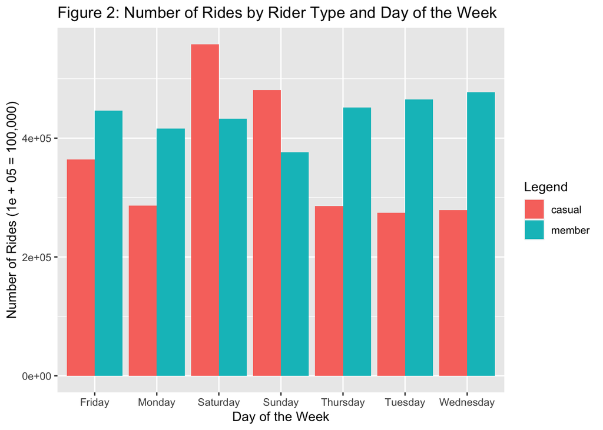

```r
ggplot(data = divvy2021) + stat_count(mapping = aes(x= day_in_week, fill = member_casual), position = "dodge") +
  ggtitle("Figure 2: Number of Rides by Rider Type and Day of the Week") + ylab("Number of Rides (1e + 05 = 100,000)") +
  xlab("Day of the Week") + labs(fill = "Legend")
```

Noticing that the days are not in the right order

```r
divvy2021$day_in_week <- ordered(divvy2021$day_in_week, levels=c("Sunday", "Monday", "Tuesday", "Wednesday", "Thursday", "Friday", "Saturday"))
```

we run the plot code again

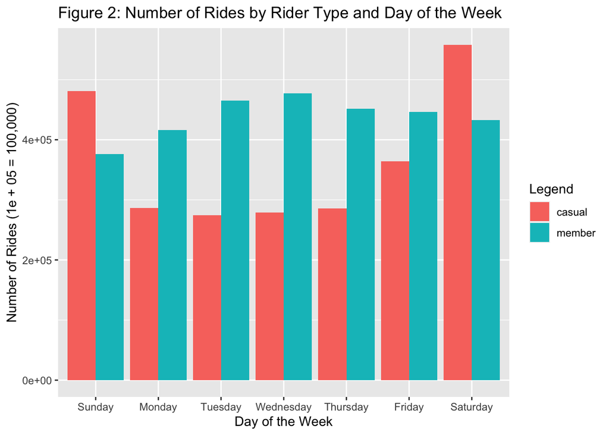

```r
ggplot(data = divvy2021) + stat_count(mapping = aes(x= day_in_week, fill = member_casual), position = "dodge") +
  ggtitle("Figure 2: Number of Rides by Rider Type and Day of the Week") + ylab("Number of Rides (1e + 05 = 100,000)") +
  xlab("Day of the Week") + labs(fill = "Legend")
```

```
## Defaulting to continuous.
```

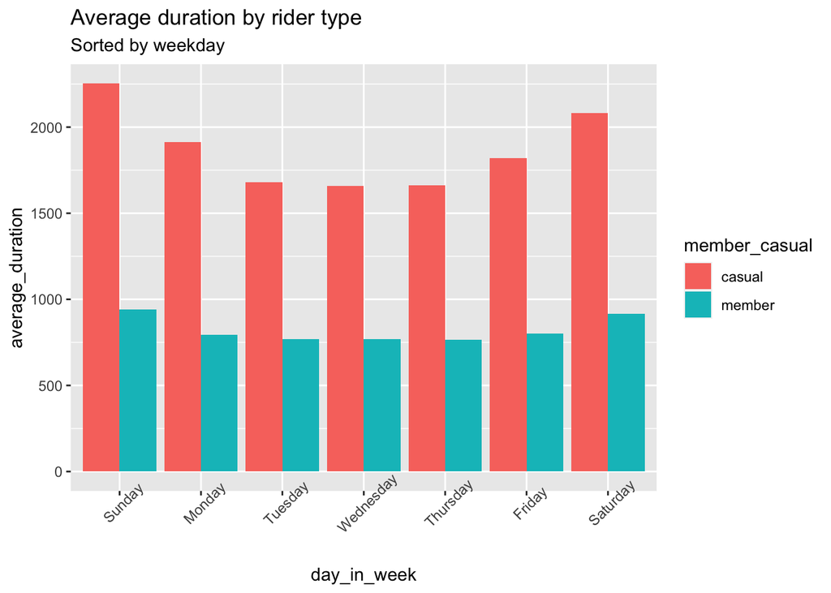

```r
divvy2021 %>%
  group_by(member_casual, day_in_week) %>%  #groups by usertype and weekday
  summarise(number_of_rides = n() ,average_duration = mean(ride_time_length)) %>%
  arrange(member_casual, day_in_week) %>%
  ggplot(aes(x = day_in_week, y = average_duration, fill = member_casual)) +
  geom_col(position = "dodge") +
  labs(title = "Average duration by rider type", subtitle = "Sorted by weekday") +
  theme(axis.text.x = element_text(angle = 45))
```

### By month

```
## Defaulting to continuous.
```

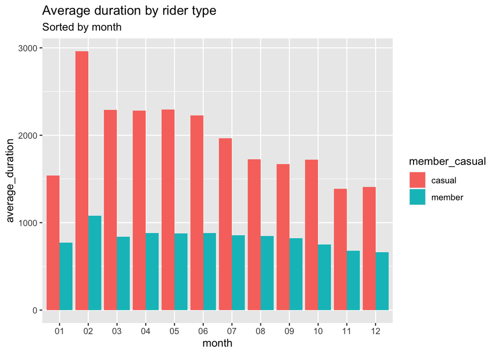

```r
divvy2021 %>%
  group_by(member_casual, month) %>%
  summarise(number_of_rides = n() ,average_duration = mean(ride_time_length)) %>%
  arrange(member_casual, month) %>%
ggplot(aes(x = month, y = average_duration, fill = member_casual)) +
  geom_col(position = "dodge") +
  labs(title = "Average duration by rider type", subtitle = "Sorted by month")
```